# IISER Advanced Bioacoustics Workshop - Abundance of unmarked animals from paired acoustic and count data

Meghan A. Beatty

February 2026

## Code purpose

There are a variety of methods to estimate abundance and/or density from acoustic data. Here, we are going to use data from simulated, spatially replicated, paired acoustic and human observer count surveys to estimate abundance. We have three goals:

1. Calculate species vocal activity rate (VAR) (e.g., # detections per sampling occasion) from simulated acoustic data.
2. Estimate abundance from simulated count data of unmarked animals using N-mixture models.
3. Relate VAR to estimated species abundance to estimate an acoustically-derived index of abundance. We will also relate VAR to raw count data for comparison.

## 1) Calculate species vocal activity rate

In a real-world use case, we would use summarized acoustic detections (e.g., from a BirdNET output) to calculate different measures of VAR. Example measures of VAR could include, but are not limited to:

- # detections per sampling occasion
- time to first to detection per sampling occasion
- time between first and last detection per sampling occasion

For simplicity, we will simulate detections per sampling occasion for an imaginary species. A sampling occasion could vary greatly depending on your species and study design. For example, if ARUs are paired with an avian point count study, you may count the number of songs detected within a 10-minute interval. If your ARU’s are paired with counts of elephants, it may be the number of bugles detected over the course of an hour. We make an assumption that if no individuals were present, no detections would be recorded (i.e., no false positives).

```r
#set seed to ensure we get the same values
set.seed(123)

#define expected (mean) number of acoustic detections per site and sampling occasion
means <- rep(c(0,5,10,15,20),10)
means
```

```
##  [1]  0  5 10 15 20  0  5 10 15 20  0  5 10 15 20  0  5 10 15 20  0  5 10 15 20
## [26]  0  5 10 15 20  0  5 10 15 20  0  5 10 15 20  0  5 10 15 20  0  5 10 15 20
```

```r
#create a site (rows) by visit (columns) dataframe to fill with a detection history
VAR <- matrix(NA, nrow = 50, ncol = 10)

#simulate detections per sampling occasion based on the expected value assigned above
for (i in 1:nrow(VAR)) {
    tmp <- rpois(ncol(VAR), lambda = means[i])
    VAR[i, ] <- tmp[1:ncol(VAR)]
  }
VAR <- as.data.frame(VAR)
head(VAR)
```

```
##   V1 V2 V3 V4 V5 V6 V7 V8 V9 V10
## 1  0  0  0  0  0  0  0  0  0   0
## 2  4  7  4  8  9  2  5  8  5   5
## 3 15 11  5  4 13 11 11 10  8  15
## 4 16  7 11 10 13 10 12 14 10  10
## 5 18 14 24 23 23 23 22 19 18  18
## 6  0  0  0  0  0  0  0  0  0   0
```

```r
#calculate mean detections per site
VAR.mean <- rowMeans(VAR); VAR.mean
```

```
##  [1]  0.0  5.7 10.3 11.3 20.2  0.0  5.5  9.8 13.9 18.9  0.0  4.5 10.7 16.0 21.4
## [16]  0.0  4.3 10.8 15.5 18.5  0.0  4.9 10.4 15.0 21.3  0.0  5.6  8.3 16.2 20.2
## [31]  0.0  4.9  8.3 15.8 19.2  0.0  4.7 11.0 16.0 20.8  0.0  5.5 10.0 14.7 19.8
## [46]  0.0  5.7 11.2 14.3 18.8
```

## 2) Estimate abundance using count data and N-mixture models

In a real-world use case, we would use data collected in human observer count surveys that were paired with ARUs. Here, we will simulate count data that meets our expectation that VAR increases with increasing abundance.

```r
#define number of sites and number of sampling occasions to match the VAR data
nSites <- 50
nOcc   <- 10

# define true abundance
  # in this we case we assume the number of animals vary between 0 and 4 per site;
  # thus, our simulated VAR data reflects that an animal calls about 5x per sampling occasion (e.g., 4 animals x 5 calls = 20 calls total)
N <- rep(c(0:4),10)

# define true detection
p <- 0.3

#create dataframe for observed counts
y <- matrix(NA, nSites, nOcc)

#simulate observed counts with imperfect detection
for(i in 1:nSites){
  y[i, ] <- rbinom(nOcc, N[i], p)
}

head(y)
```

```
##      [,1] [,2] [,3] [,4] [,5] [,6] [,7] [,8] [,9] [,10]
## [1,]    0    0    0    0    0    0    0    0    0     0
## [2,]    0    1    0    0    0    0    1    1    0     0
## [3,]    0    1    1    1    0    1    2    1    0     0
## [4,]    0    0    1    0    1    1    1    1    1     1
## [5,]    2    1    0    3    2    1    0    1    1     2
## [6,]    0    0    0    0    0    0    0    0    0     0
```

Next we will take our simulated observed counts and estimate abundance at each site using an N-mixture model in the ‘unmarked’ package, incorporating imperfect detection of individuals at each site.

```r
library(unmarked)

#define site names
sites <- paste0("site", 1:50)

#create the unmarked object
umf <- unmarkedFramePCount(y = y, siteCovs = data.frame(sites=as.factor(sites)))

#run the unmarked model
model1 <- pcount(~1 ~1, umf, K = 25)
model1
```

```
##
## Call:
## pcount(formula = ~1 ~ 1, data = umf, K = 25)
##
## Abundance (log-scale):
##  Estimate   SE    z  P(>|z|)
##     0.461 0.13 3.55 0.000381
##
## Detection (logit-scale):
##  Estimate    SE     z  P(>|z|)
##    -0.528 0.127 -4.17 3.02e-05
##
## AIC: 872.1707
## Number of sites: 50
```

```r
#check we are close to our defined 'p'
plogis(coef(model1, type="det"))
```

```
##    p(Int)
## 0.3708798
```

```r
#empirical Bayes estimation of random effects
model1re <- ranef(model1); model1re
```

```
##             Mean Mode 2.5% 97.5%
##  [1,] 0.01539923    0    0     0
##  [2,] 1.06000016    1    1     2
##  [3,] 2.11126673    2    2     3
##  [4,] 1.56208268    1    1     3
##  [5,] 3.32353623    3    3     4
##  [6,] 0.01539923    0    0     0
##  [7,] 1.11515500    1    1     2
##  [8,] 1.06000016    1    1     2
##  [9,] 2.11126673    2    2     3
## [10,] 3.83411182    4    3     5
## [11,] 0.01539923    0    0     0
## [12,] 1.06000016    1    1     2
## [13,] 2.23039591    2    2     3
## [14,] 2.56424577    2    2     4
```

[output cut: 36 more lines]

```r
#extract the mean estimated abundance per site
pred <- data.frame(abund.est = bup(model1re, state = "mean"))
#estimated summed abundance across sites
sum(bup(model1re))
```

```
## [1] 79.27531
```

```r
#actual summed abundance across sites
sum(N)
```

```
## [1] 100
```

```r
#round estimated abundance to integer for use below
pred$abund.est <- round(pred$abund.est, 0)
```

## 3) Relate estimated species abundance and raw count data to vocal activity rate

We will fit generalized linear models with a Poisson distribution because we are using count data. However, other distributions may be needed depending on the behavior of your data (e.g., a negative binomial or zero-inflated Poisson; see lecture). We will test estimated abundance and maximum observed counts as the response variables and VAR as the predictor.

```r
#add the maximum raw count per site (i.e., naive abundance) to the prediction dataframe
pred$max.count <- apply(y, 1, max)

#add mean VAR per site to the prediction dataframe
pred$VAR <- VAR.mean

#look at correlations between counts and VAR
cor(pred[, c("VAR", "abund.est", "max.count")])
```

```
##                 VAR abund.est max.count
## VAR       1.0000000 0.9051241 0.8912585
## abund.est 0.9051241 1.0000000 0.9465121
## max.count 0.8912585 0.9465121 1.0000000
```

```r
#relate estimated abundance to VAR
m.abund <- glm(abund.est ~ VAR, family = poisson, data = pred)
summary(m.abund)
```

```
##
## Call:
## glm(formula = abund.est ~ VAR, family = poisson, data = pred)
##
## Coefficients:
##             Estimate Std. Error z value Pr(>|z|)
## (Intercept) -0.81785    0.29506  -2.772  0.00558 **
## VAR          0.09988    0.01868   5.346 9.01e-08 ***
## ---
## Signif. codes:  0 '***' 0.001 '**' 0.01 '*' 0.05 '.' 0.1 ' ' 1
##
## (Dispersion parameter for poisson family taken to be 1)
##
##     Null deviance: 49.040  on 49  degrees of freedom
## Residual deviance: 16.104  on 48  degrees of freedom
## AIC: 119.4
##
## Number of Fisher Scoring iterations: 5
```

```r
#relate maximum observed count to VAR
m.count <- glm(max.count ~ VAR, family = poisson, data = pred)
summary(m.count)
```

```
##
## Call:
## glm(formula = max.count ~ VAR, family = poisson, data = pred)
##
## Coefficients:
##             Estimate Std. Error z value Pr(>|z|)
## (Intercept) -0.80557    0.30032  -2.682  0.00731 **
## VAR          0.09129    0.01932   4.725  2.3e-06 ***
## ---
## Signif. codes:  0 '***' 0.001 '**' 0.01 '*' 0.05 '.' 0.1 ' ' 1
##
## (Dispersion parameter for poisson family taken to be 1)
##
##     Null deviance: 41.047  on 49  degrees of freedom
## Residual deviance: 15.878  on 48  degrees of freedom
## AIC: 115.88
##
## Number of Fisher Scoring iterations: 5
```

Let’s compare the results on a plot.

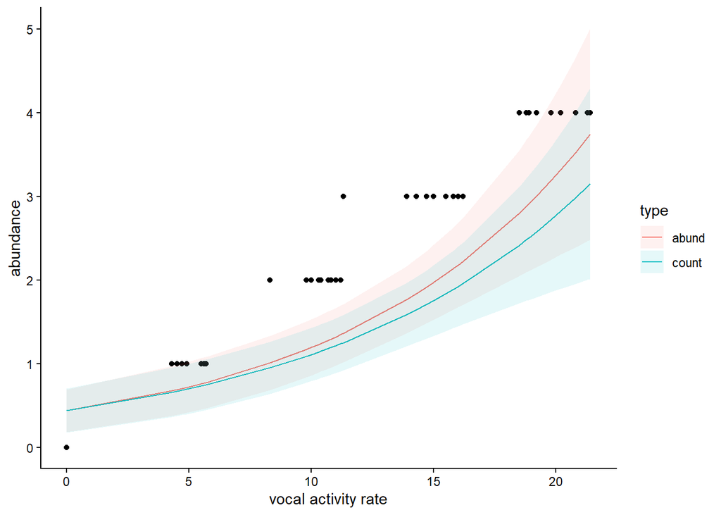

```r
#create data for predictions
newdata <- as.data.frame(pred)

#predict abundance
abund.pred <- predict(m.abund, newdata = newdata, type = "response", se.fit = TRUE)
# 95% CI
abund.pred <- data.frame(
  fit   = abund.pred$fit,
  se    = abund.pred$se.fit,
  lower = abund.pred$fit - 1.96 * abund.pred$se.fit,
  upper = abund.pred$fit + 1.96 * abund.pred$se.fit
  )
#format data for plotting
abund.pred$type <- "abund"
abund.pred$abund <- N
abund.pred$VAR <- newdata$VAR

#predict observed counts
count.pred <- predict(m.count, newdata = newdata, type = "response", se.fit = TRUE)
# 95% CI
count.pred <- data.frame(
  fit   = count.pred$fit,
  se    = count.pred$se.fit,
  lower = count.pred$fit - 1.96 * count.pred$se.fit,
  upper = count.pred$fit + 1.96 * count.pred$se.fit
  )
#format data for plotting
count.pred$type <- "count"
count.pred$abund <- N
count.pred$VAR <- newdata$VAR

#combine dataframes for plotting
plot <- rbind(abund.pred, count.pred)

#plot results
library(ggplot2)
ggplot(plot) +
  geom_line(aes(x = VAR, y = fit, color = type))  +
  geom_point(aes(x = VAR, y = abund)) +
  geom_ribbon(aes(x = VAR, ymin = lower, ymax = upper, fill = type), alpha = 0.1) +
  #facet_wrap(~type) + #to make each plot in it's own pane
  ylab("abundance") + xlab("vocal activity rate") +
  theme_classic()
```

Was VAR a better predictor for estimated abundance or the maximum observed counts? How does this change as we change our detection probability (p) defined above?